# Raport ilustrare repartitii discrete si continue

Constantin Gabriel-Adrian, Hernest Mihai, Richiteanu Mihai-Sebastian | Grupa 242

### Ce sunt *variabilele aleatoare*?

Variabila aleatoare este constituita de conceptul de a asocia o valoare numerica reala unui eveniment elementar.

Astfel, o variabila aleatoare nu este altceva decat o functie reala $x:\Omega\rightarrow\mathbb{R}$ care are proprietatea ca $\{\omega \,|\, X(\omega)\leq x\} \in {F}, \forall \,x \in \mathbb{R}$ , unde $(\Omega, F, \mathbb{P})$ un camp de probabilitate.

### Tipuri de *variabile aleatoare* :

Putem distinge 2 tipuri de variabile aleatoare:

- discrete (cel mult numarabile)
- continue (atunci cand intr-un experiment masuram o anumita cantitate)

### Cateva notiuni elementare despre repartitii, functia de masa/de densitate, functia de repartitie

- repartitia
  $$\mathbb{P}_{X}(A) = \mathbb{P}(X \in A), \forall A \in \mathbb{R}$$
1. *variabile aleatoare*
   - repartitia
     $$\mathbb{P} (x \in A) = \sum_{x \in A \cap X(\Omega)}{p_{x}(x)}$$
   - functia de masa
     $$p_{x} (x) = \mathbb{P}(X=x), \forall x \in \mathbb{R}$$
   - functia de repartitie
     $$F(x) = \mathbb{P}(X \leq x), \forall x \in \mathbb{R}$$
2. *variabile continue*
   - repartitia
     $$\mathbb{P}(x \in A) = \int _{A}{f(x)dx}, \forall A \subseteq \mathbb{R}$$
   - functia de densitate
     $$f(x), \, \text{unde } f(x) \geq 0$$
   - functia de repartitie
     $$F(x)=\mathbb{P} (X \leq x), \, \forall x \in \mathbb{R}$$

### Cum a decurs implementarea in *R* cu libraria *Shiny*?

Am folosit libraria *Shiny* pentru a realiza o pagina web in care sa afisam toate figurile. Astfel, pentru o navigare facila am implementat fiecare figura in propriul *tab panel*, usor navigabila din partea de sus a ferestrei.

In partea personalizata vom regasi slidere custom (de exemplu pentru lambda, probabilitate) precum si 3 figuri(grafice): functia de masa/densitate, functia de repartitie si ilustrarea prin hasurare a probabilitatii selectate de utilizator.

Functiile de masa/densitate si de repartitie au fost calculate folosind functiile predefinite(de exemplu pentru repartitia binomiala avem *dbinom* si *pbinom*):

```
            fm = function(x){
                return (dbinom(x, size = NrIncercari, prob = ProbBit))
            }
            F = function(x){
                return (pbinom(x, size = NrIncercari, prob = ProbBit))
            }
```

Pentru realizarea figurilor am folosit atat *plot* cat si *ggplot* (libraria ggplot2), de exemplu:

```
            # fct masa
                x = seq(0, NrBiti, by=1)
                y = fm(x)
                plot(x, y, lwd=5)
                segments(x, 0, x, y, col="red")
            # fct rept
                x = seq(-1, NrBiti, length.out = 1000)
                y = F(x)
                plot(x, y, type= "l", col="red")
```

Hasurarea probabilitatii a fost realizata cu ajutorul functiei *ploygon*

```
            if(SelectProb=="P(x<=a)"){
              x = seq(-10,a,length.out = 1000)
              y = fd2(x)
              polygon(c(-10,x,a), c(-10,y,0), col="light blue")
            }else if(SelectProb=="P(x>=b)"){
              x = seq(b,10,length.out = 1000)
              y = fd2(x)
              polygon(c(b,x,10), c(0,y,0), col="light blue")
            }else{
              x = seq(a,b,length.out = 1000)
              y = fd2(x)
              polygon(c(a,x,b), c(0,y,0), col="light blue")
            }
```

### Codul complet si figurile:

Pentru o experienta completa (UI-interactiv, slidere care se actualizeaza automat) se recomanda utilizarea aplicatiei .R atasata.

### Ex1

Presupunem ca avem un experiment aleator. Ne interesam la realizarea unui eveniment A, considerand ca sansa de realizare a lui A este p. Aruncam o moneda cu probabilitatea de p (prob).

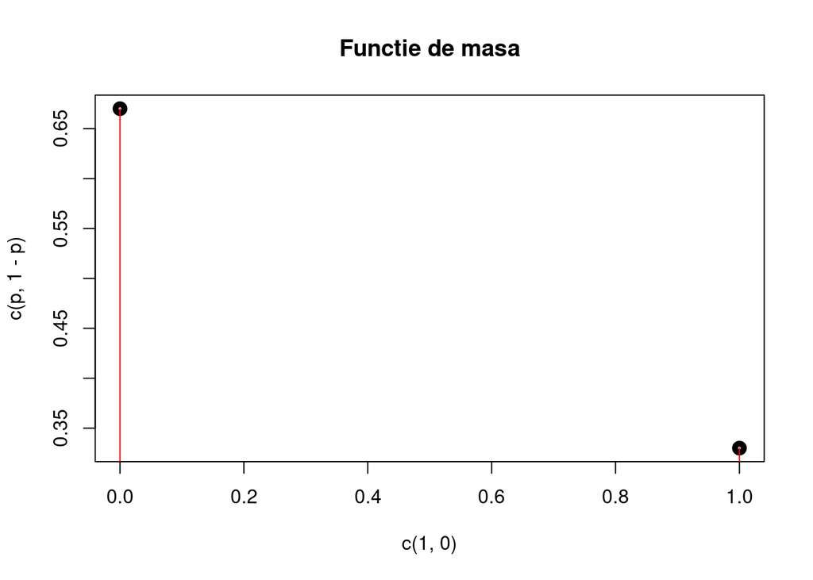

```r
            prob = 0.33
            a = 0
            FctMasa = function(p){
                plot(c(1,0),c(p,1-p), lwd=5, main="Functie de masa")
                segments(c(1,0), 0, c(1,0), c(p,1-p), col="red")
            }


            F = function(x,p){
                if (x<0){
                    y=0
                }else if (x<1){
                    y = 1-p
                }else{
                    y=1
                }
                return(y)
            }

            P = function(p, a, b=NULL, param=NULL)
            {
                if(is.null(b))
                {
                    if(is.null(param))
                    {
                        return(F(a, p))
                    }
                    else
                    {
                        return (1 - F(a, p))
                    }
                }
                else
                {
                    return (F(b, p) - F(a, p))
                }
            }

            fctMasa <- ({
                FctMasa(prob)
            })
```

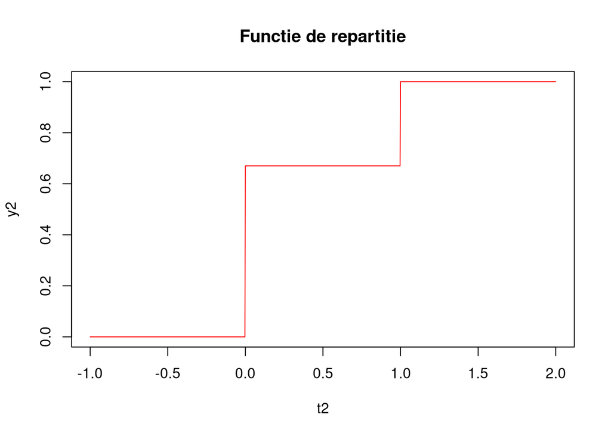

```r
            fctRep <- ({
                F2 = Vectorize(F, vectorize.args = "x")
                t2 = seq(-1,2,length.out = 1000)
                y2 = F2(t2,prob)
                plot(t2, y2, type= "l", col="red", main="Functie de repartitie")
            })
```

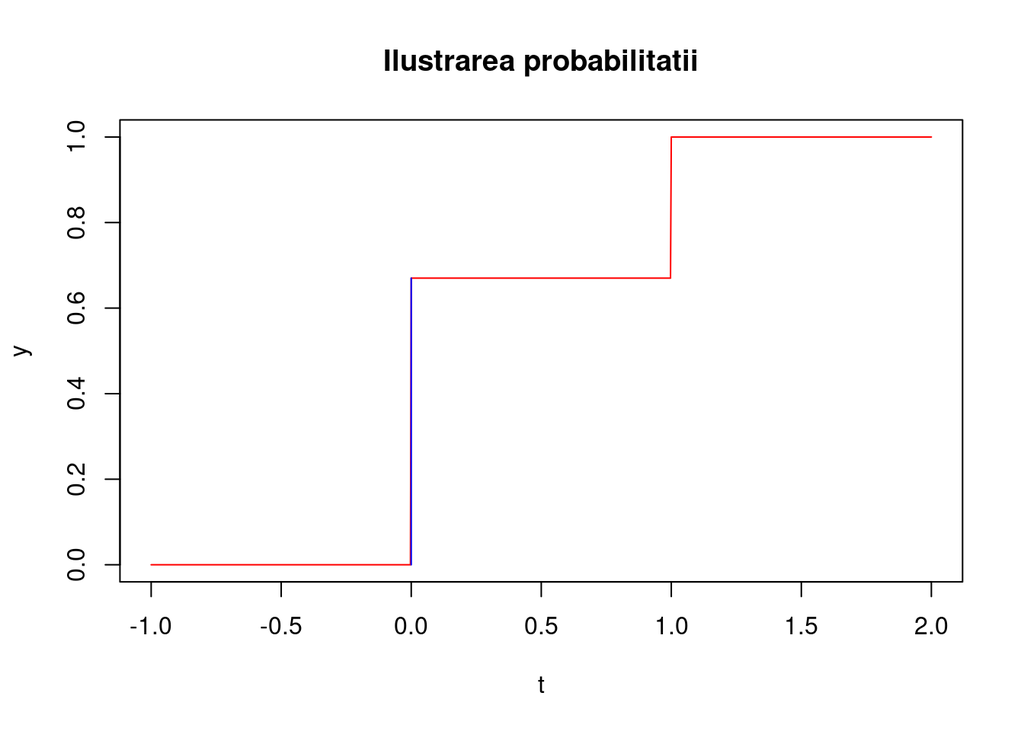

```r
            SelectProb = "P(x<=a)"


            fctProb <- ({

                F = Vectorize(F, vectorize.args = "x")
                t = seq(-1,2,length.out = 1000)
                y = F(t,prob)
                plot(t, y, type= "l", col="red", main="Ilustrarea probabilitatii")

                if(SelectProb=="P(x<=a)"){
                    x = seq(0,a)
                    y=F(x, prob)


                    for(i in 1:length(x)){
                        tmp = 0
                        if(i==1)
                            tmp = 0
                        else
                            tmp = y[i-1]
                        lines(c(x[i],x[i]), c(tmp,y[i]), col="blue")
                    }

                }else if(SelectProb=="P(x>=b)"){
                    x = seq(b,2)
                    y = F(x,prob)
                    for(i in 1:length(x)){
                        tmp = 0
                        if(i==1)
                            tmp = 0
                        else
                            tmp = y[i-1]
                        lines(c(x[i],x[i]), c(tmp,y[i]), col="blue")
                    }
                }else{
                    x = seq(a,b)
                    y = F(x,prob)
                    for(i in 1:length(x)){
                        tmp = 0
                        if(i==1)
                            tmp = 0
                        else
                            tmp = y[i-1]
                        lines(c(x[i],x[i]), c(tmp,y[i]), col="blue")
                    }
                }

            })
```

```r
            if(SelectProb=="P(x<=a)"){
                c("Probability: ", P(prob, a))
            }else if(SelectProb=="P(x>=b)"){
                c("Probability: ", P(prob, b, param = 1)+F(b, prob))
            }else{
                c("Probability: ", P(prob, a, b)+F(a, prob))
            }
```

```
## [1] "Probability: " "0.67"
```

### Ex 2

Modelam repartitia data de o v.a continua cu formula
$$f = (e^x) / ((1+e^x)^2)$$

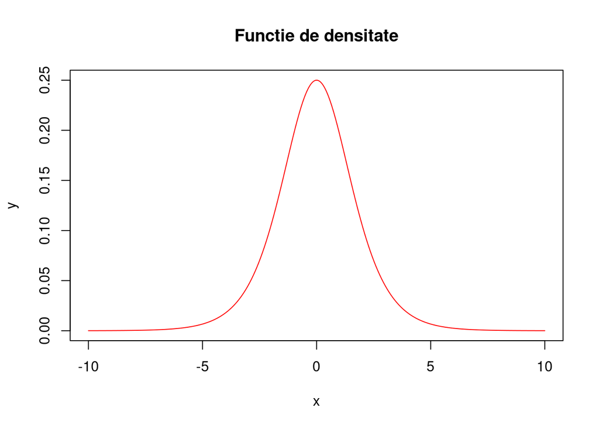

```r
fd2 = function(x){
         return (exp(x)/(1 + exp(x))^2)
}
F2 = function(x){
      return (integrate(fd2,lower = -Inf, upper = x)$value)
}
F2 = Vectorize(F2, vectorize.args = "x")
a=0
b=1
# fct masa
x = seq(-10, 10, length.out = 1000)
y = fd2(x)
# fct repartitie
plot(x, y, type= "l", col="red", main="Functie de densitate")
```

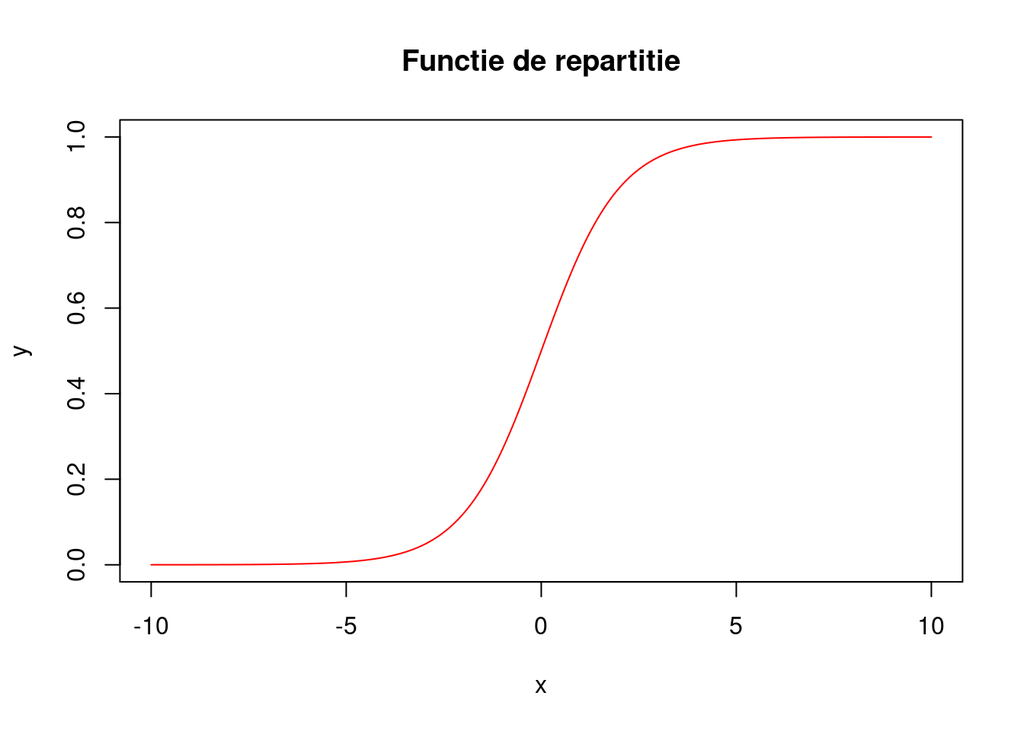

```r
x = seq(-10, 10, length.out = 1000)
y = F2(x)

plot(x, y, type= "l", col="red", main="Functie de repartitie")
```

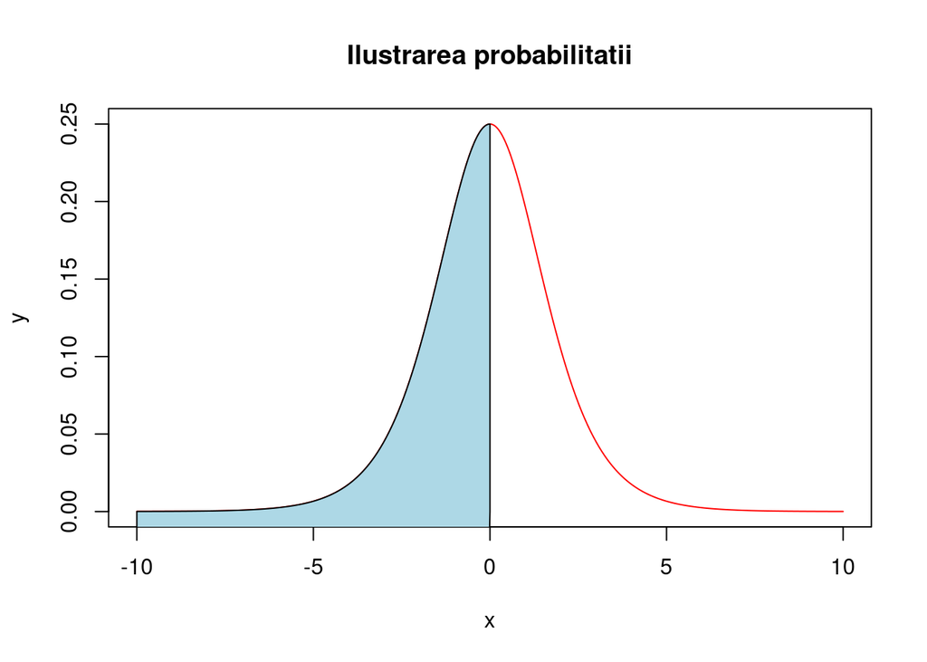

```r
x = seq(-10, 10, length.out = 1000)
y = fd2(x)

plot(x, y, type= "l", col="red", main="Ilustrarea probabilitatii")
SelectProb = "P(x<=a)"
if(SelectProb=="P(x<=a)"){
  x = seq(-10,a,length.out = 1000)
  y = fd2(x)
  polygon(c(-10,x,a), c(-10,y,0), col="light blue")
}else if(SelectProb=="P(x>=b)"){
  x = seq(b,10,length.out = 1000)
  y = fd2(x)
  polygon(c(b,x,10), c(0,y,0), col="light blue")
}else{
  x = seq(a,b,length.out = 1000)
  y = fd2(x)
  polygon(c(a,x,b), c(0,y,0), col="light blue")
}
```

```r
  P2 = function(a, b=NULL, param=NULL)
  {
    if(is.null(b))
    {
       if(is.null(param))
       {
          return(F2(a))
       }
       else
       {
          return (1 - F2(a))
       }
    }
    else
    {
          return (F2(b) - F2(a))
    }
}


if(SelectProb=="P(x<=a)"){
  c("Probability: ", P2(a))
}else if(SelectProb=="P(x>=b)"){
  c("Probability: ", P2(b, param = 1))
}else{
  c("Probability: ", P2( a, b))
}
```

```
## [1] "Probability: "     "0.499999999703109"
```

### Ex 3

Repartitia exponentiala in functie de un parametru lambda

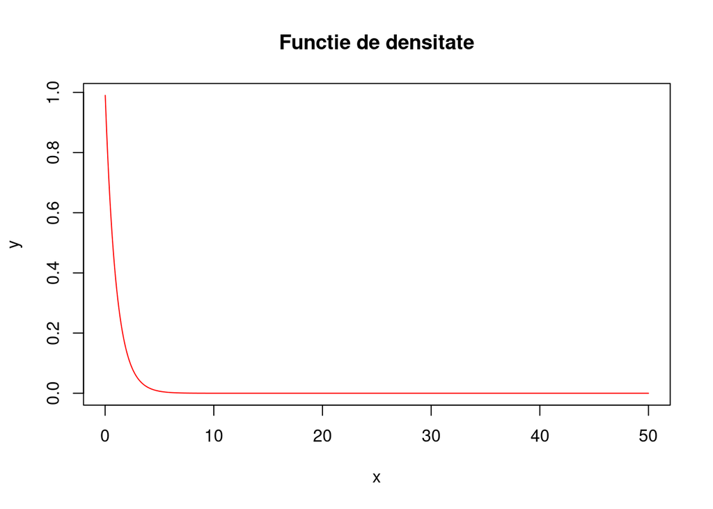

```r
            lmb3 = 1
            a = 0
            b = 1
            fd3 = function(x){
                    return (lmb3*exp(-lmb3*x))
            }
            F3 = function(x){
                return (integrate(fd3,lower = 0, upper = x)$value)
            }
            F3 = Vectorize(F3, vectorize.args = "x")

            x = seq(0.01, 50, length.out = 1000)
            y = fd3(x)
            plot(x, y, type= "l", col="red", main="Functie de densitate")
```

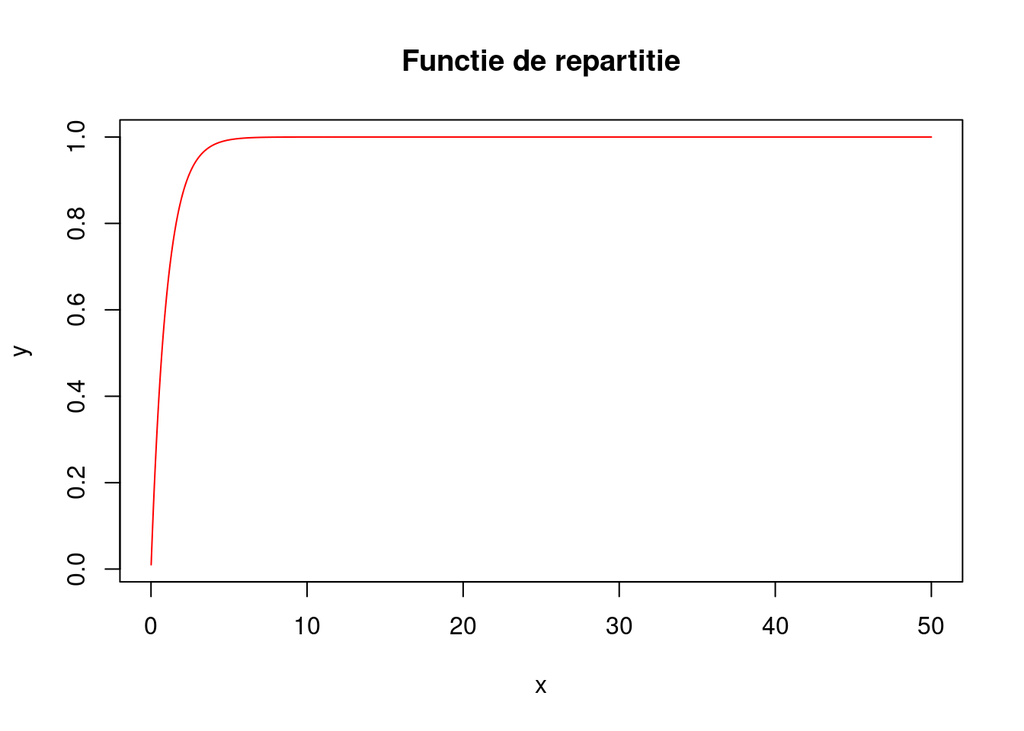

```r
            x = seq(0.01, 50, length.out = 1000)
            y = F3(x)
            plot(x, y, type= "l", col="red", main="Functie de repartitie")
```

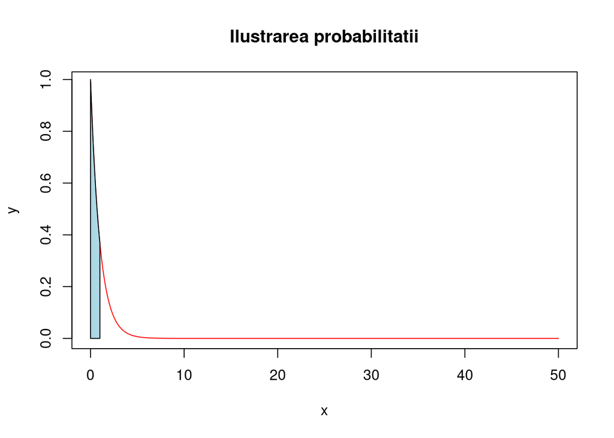

```r
            x = seq(0.01, 50, length.out = 1000)
            y = fd3(x)
                #mini = min(y)
            plot(x, y, type= "l", col="red", main="Ilustrarea probabilitatii")
            SelectProb = "caz3"
            if(SelectProb=="P(x<=a)"){
                  x = seq(0.01,a,length.out = 1000)
                  y = fd3(x)
                  polygon(c(0, x, a), c(0,y,0), col="light blue")
            }else if(SelectProb=="P(x>=b)"){
                  x = seq(b,50,length.out = 1000)
                  y = fd3(x)
                  polygon(c(b, x), c(0, y), col="light blue")
            }else{
                  x = seq(a,b,length.out = 1000)
                  y = fd3(x)
                  polygon(c(a, x, b), c(0,y,0), col="light blue")
                }
```

```r
            P3 = function(a, b=NULL, param=NULL)
            {
                if(is.null(b))
                {
                    if(is.null(param))
                    {
                        return(F3(a))
                    }
                    else
                    {
                        return (1 - F3 (a))
                    }
                }
                else
                {
                    return (F3(b) - F3(a))
                }
            }
            SelectProb = "caz3"
            if(SelectProb=="P(x<=a)"){

                    c("Probability: ", P3(a))

                }else if(SelectProb=="P(x>=b)"){

                    c("Probability: ", P3(b, param = 1))

                }else{

                    c("Probability: ", P3(a, b))

                }
```

```
## [1] "Probability: "     "0.632120558828558"
```

### Ex4

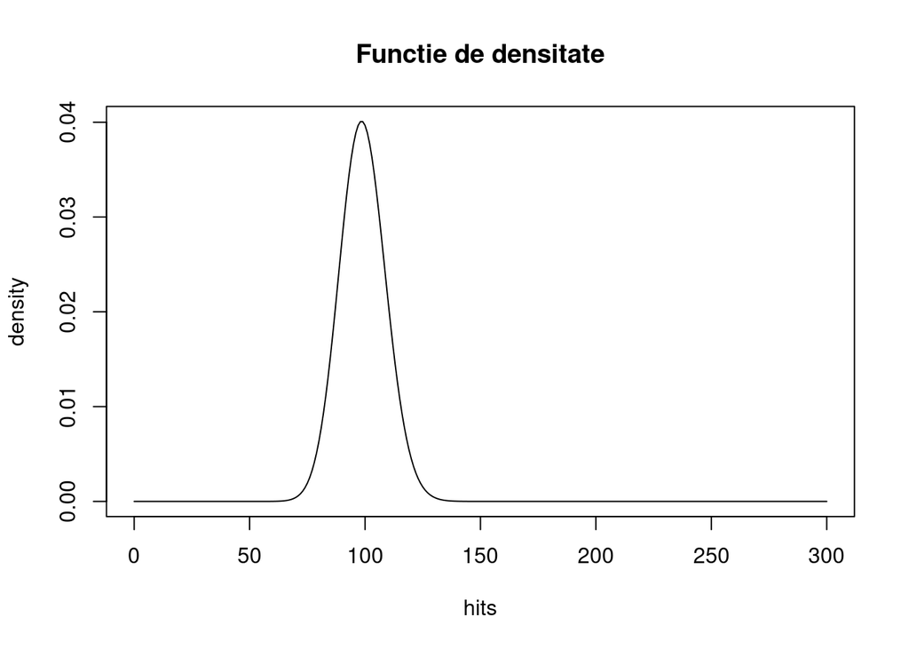

```r
            prob2 = 0.33
            NrAruncari= 300
            a = 100

            fd4 = function(x)
            {
                return(dpois(x, prob2*NrAruncari , log = FALSE))
            }

            F4 = function(xx)
            {
                return (ppois(q = xx, lambda = NrAruncari*prob2, lower.tail = TRUE))
            }

            hits <- 0:NrAruncari
            density <- fd4(hits)
            plot (x = hits,y=density,type="l", main="Functie de densitate")
```

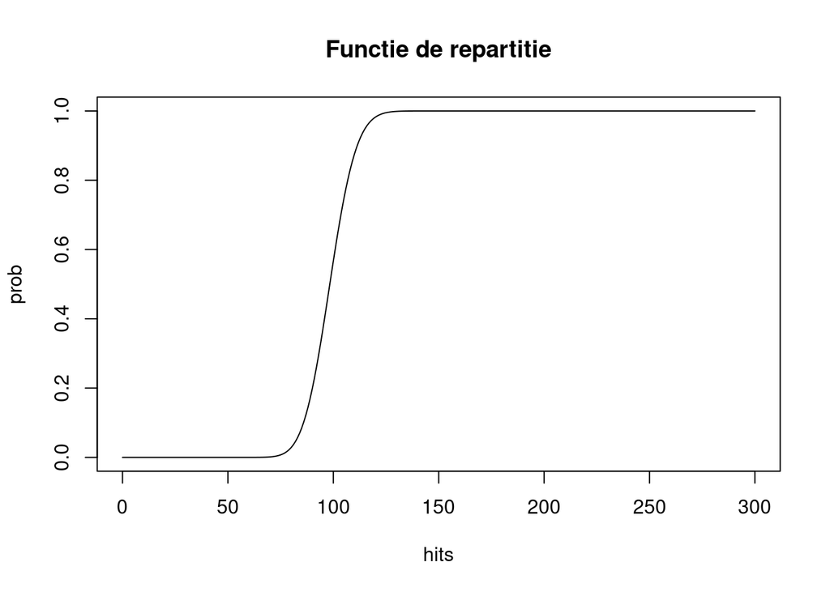

```r
            prob <- F4(hits)
            plot (x = hits,y=prob,type="l", main="Functie de repartitie")
```

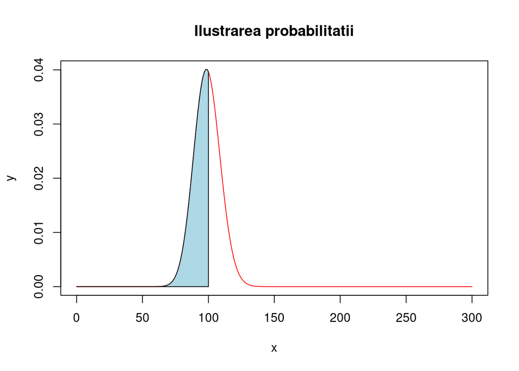

```r
            x = 0:NrAruncari
            y = fd4(x)
            plot(x, y, type= "l", col="red", main="Ilustrarea probabilitatii")

            SelectProb = "P(x<=a)"

            if(SelectProb=="P(x<=a)"){
                 polygon(c(0,x[x<=a],a), c(0,y[x<=a],0), col="light blue")
            }else if(SelectProb=="P(x>=b)"){
                polygon(c(b,x[b<=x],NrAruncari),c(0,y[b<=x],0), col="light blue")
            }else{
                x = seq(a,b)
                y = fd4(x)
                polygon(c(a,x,b), c(0,y,0), col="light blue")
            }
```

```r
            P4 = function(a, b=NULL, param=NULL)
            {
                if(is.null(b))
                {
                    if(is.null(param))
                    {
                        return(F4(a))
                    }
                    else
                    {
                        return (1 - F4 (a))
                    }
                }
                else
                {
                    return (F4(b) - F4(a))
                }
            }



            if(SelectProb=="P(x<=a)"){
                c("Probability: ", P4(a))
            }else if(SelectProb=="P(x>=b)"){
                c("Probability: ", P4(b, param = 1))
            }else{
                c("Probability: ", P4(a, b))
            }
```

```
## [1] "Probability: "     "0.566356526812556"
```

### Ex 5

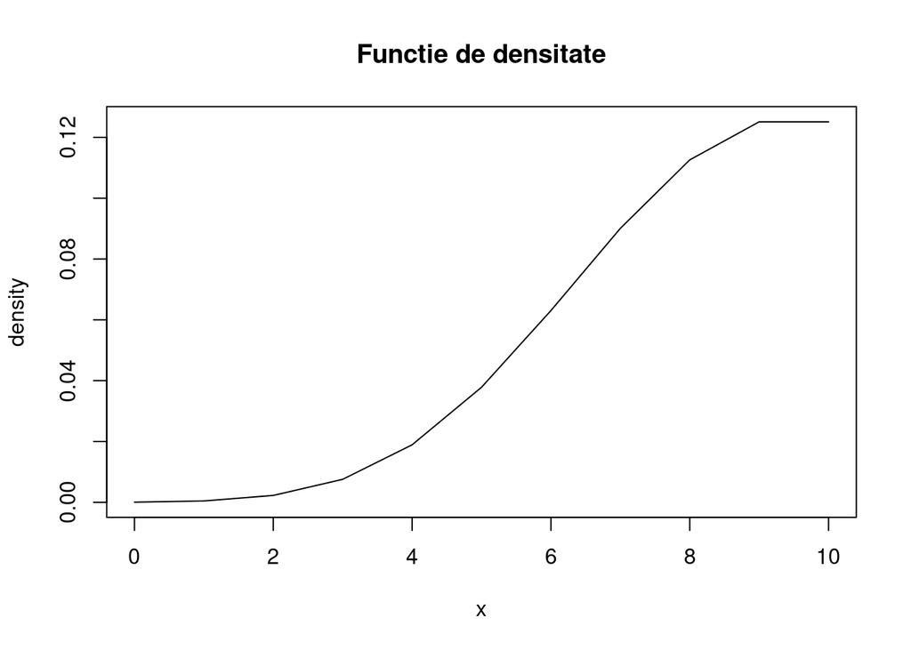

```r
            NrInfectati = 1000
            prob_infectare = 0.01
            b = 7

            fd5 = function(x)
            {
                return(dpois(x = x, lambda = NrInfectati * prob_infectare))
            }

            F5 = function(xx)
            {
                return (ppois(q = xx, lambda = NrInfectati * prob_infectare, lower.tail = TRUE))
            }

            fctMasa <- ({
                x <- 0:10
                density <- fd5(x)
                plot (x = x,y=density,type="l", main="Functie de densitate")
            })
```

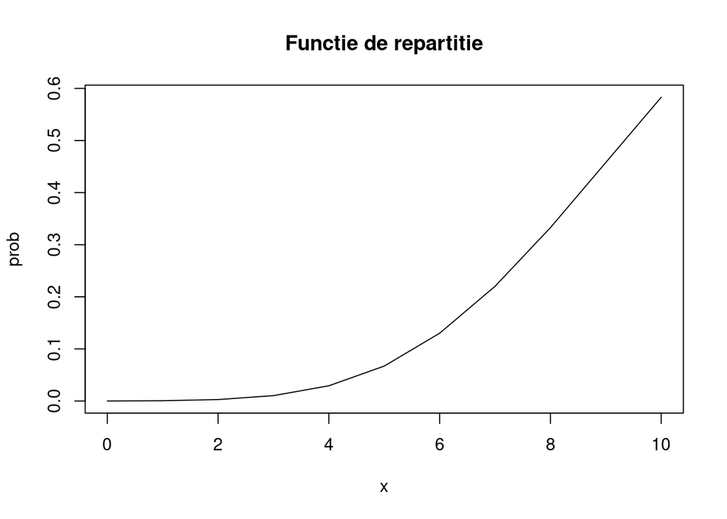

```r
            fctRep <- ({
                x <- 0:10
                prob <- F5(x)
                plot (x = x,y=prob,type="l", main="Functie de repartitie")
            })
```

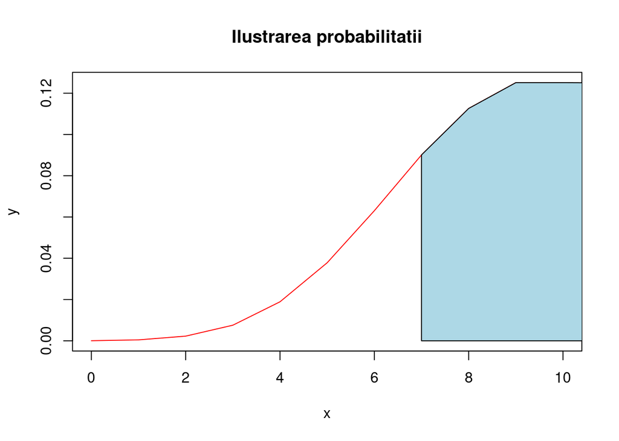

```r
            SelectProb = "P(x>=b)"

            fctProb <- ({
                x = 0:10
                y = fd5(x)

                plot(x, y, type= "l", col="red", main="Ilustrarea probabilitatii")

                if(SelectProb=="P(x<=a)"){
                    polygon(c(0,x[x<=a],a), c(0,y[x<=a],0), col="light blue")
                }else if(SelectProb=="P(x>=b)"){
                    polygon(c(b,x[b<=x],NrInfectati),c(0,y[b<=x],0), col="light blue")
                }else{
                    x = seq(a,b)
                    y = fd5(x)
                    polygon(c(a,x,b), c(0,y,0), col="light blue")

                }
            })
```

```r
            P5 = function(a, b=NULL, param=NULL)
            {
                if(is.null(b))
                {
                    if(is.null(param))
                    {
                        return(F5(a))
                    }
                    else
                    {
                        return (1 - F5 (a))
                    }
                }
                else
                {
                    return (F5(b) - F5(a))
                }
            }



            if(SelectProb=="P(x<=a)"){
                c("Probability: ", P5(a))
            }else if(SelectProb=="P(x>=b)"){
                c("Probability: ", P5(b, param = 1))
            }else{
                c("Probability: ", P5(a, b))
            }
```

```
## [1] "Probability: "     "0.779779353398301"
```

### Ex 6 (Repartitie binomiala pentru v.a. discreta)

Fie un bit care este transmis pe un canal bruiat si are probabilitatea *p* sa fie transmis incorect. Pentru a imbunatati fiabilitatea comunicarii, este transmis de *n* ori, unde *n* impar Presupunem ca avem un decodor care decide care bit e corect dupa numarul majoritar de biti transmisi. *n* si *p* dati ca parametru, *x*-nr biti transmisi cu eroare, *X~B(n, p)*

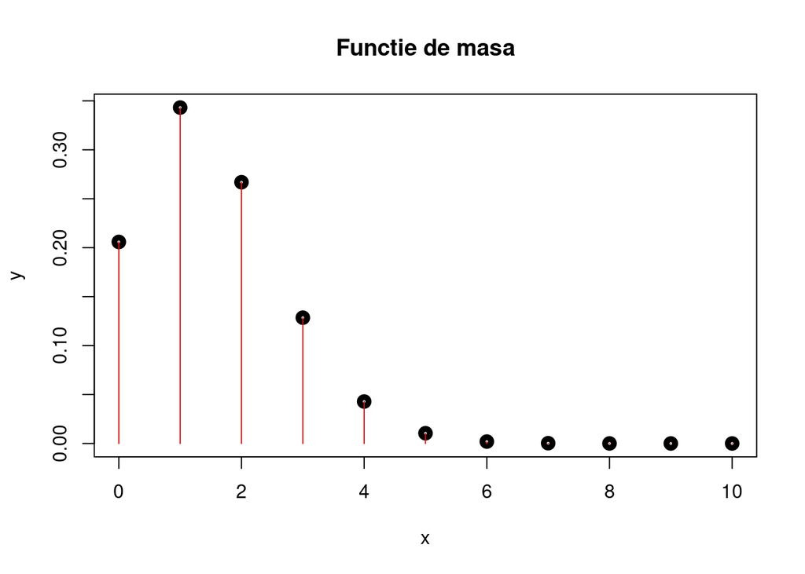

```r
            # 6 G~~~~~~~~~~~~~~~~~~~~~~~~~~~~~~~~~~~~~~~~~~~~~~~~~~~~~~~~~~~~~~~~~~~~~~~~~~~~~~~~~~~~~~~~~

            ProbBit = 0.1
            NrIncercari = 15
            NrBiti = 10

            a = 2
            b = 4

            fm = function(x){
                return (dbinom(x, size = NrIncercari, prob = ProbBit))
            }
            F = function(x){
                return (pbinom(x, size = NrIncercari, prob = ProbBit))
            }
            F = Vectorize(F, vectorize.args = "x")
            # fct masa
                x = seq(0, NrBiti, by=1)
                y = fm(x)
                plot(x, y, lwd=5, main="Functie de masa")
                segments(x, 0, x, y, col="red")
```

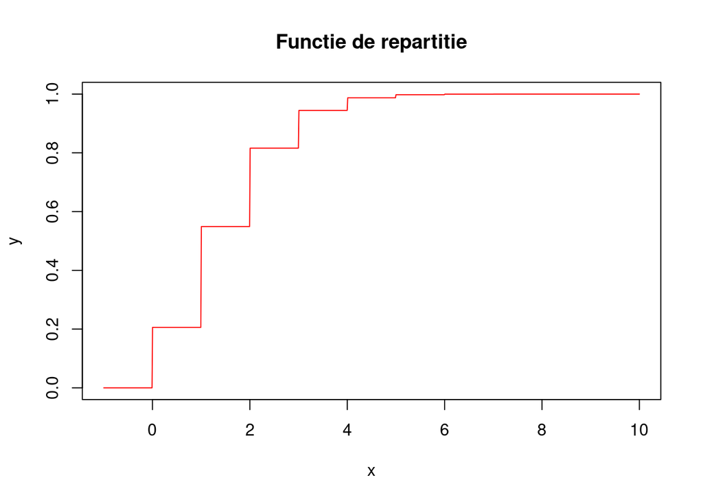

```r
            # fct rept
                x = seq(-1, NrBiti, length.out = 1000)
                y = F(x)
                plot(x, y, type= "l", col="red", main="Functie de repartitie")
```

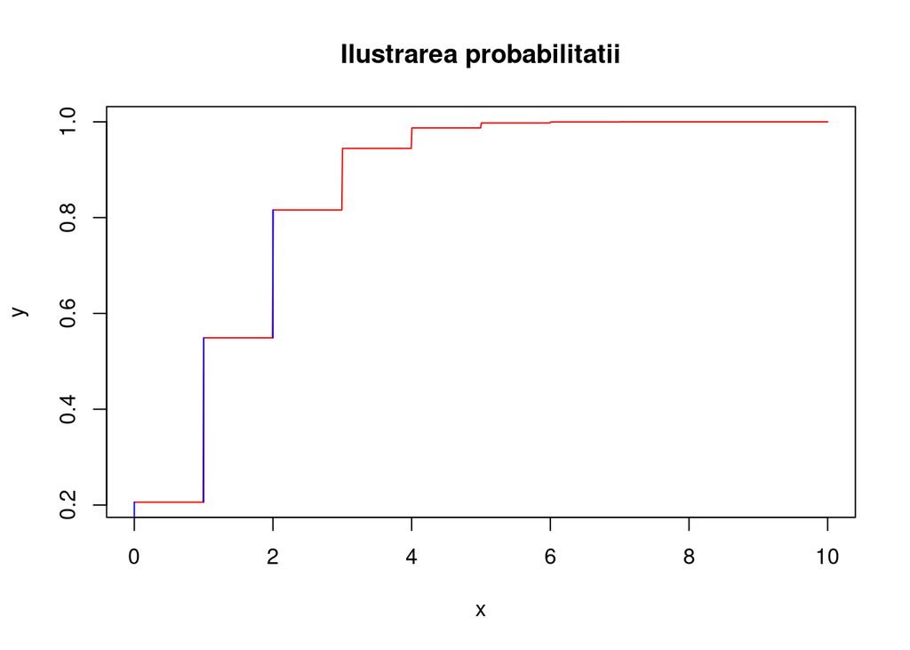

```r
                x = seq(0, NrBiti, length.out = 1000)
                y = F(x)
                plot(x, y, type= "l", col="red", main="Ilustrarea probabilitatii")

                SelectProb = "P(x<=a)"

                if(SelectProb=="P(x<=a)"){
                    x = seq(0, a)
                    y = F(x)
                    for(i in 1:length(x)){
                        tmp = 0
                        if(i==1)
                            tmp = 0
                        else
                            tmp = y[i-1]
                        lines(c(x[i],x[i]), c(tmp,y[i]), col="blue")
                    }
                }else if(SelectProb=="P(x>=b)"){
                    x = seq(b, NrBiti)
                    y = F(x)
                    for(i in 1:length(x)){
                        tmp = 0
                        if(i==1)
                            tmp = 0
                        else
                            tmp = y[i-1]
                        lines(c(x[i],x[i]), c(tmp,y[i]), col="blue")
                    }
                }else{
                    x = seq(a, b)
                    y = F(x)
                    for(i in 1:length(x)){
                        tmp = 0
                        if(i==1)
                            tmp = 0
                        else
                            tmp = y[i-1]
                        lines(c(x[i],x[i]), c(tmp,y[i]), col="blue")
                    }
                }
```

```r
            P = function(a, b=NULL, param=NULL)
            {
                if(is.null(b))
                {
                    if(is.null(param))
                    {
                        return(F(a))
                    }
                    else
                    {
                        return (1 - F(a))
                    }
                }
                else
                {
                    return (F(b) - F(a))
                }
            }
                if(SelectProb=="P(x<=a)"){
                        c("Probability: ", P(a))
                }else if(SelectProb=="P(x>=b)"){
                        c("Probability: ", P(b, param = 1)+fm(b))
                }else{
                        c("Probability: ", P(a, b)+fm(a))
                }
```

```
## [1] "Probability: "     "0.815938930893609"
```

### Ex 7 - Repartitie normala

Se calculeaza probabilitatea ca IQ-ul unei persoane sa se afle intr-un interval [a,b], fiind date media si deviatia standard

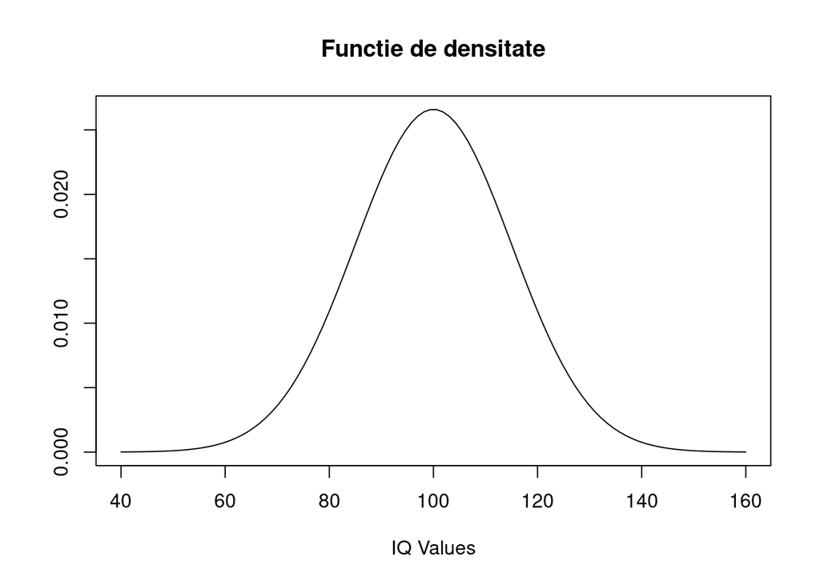

```r
                Mean = 100
                StDev = 15
                a = 80
                b = 120
                fd7 = function(x){
                    return (dnorm(x,  Mean, StDev))
                }
                F7 = function(x){
                    # return (integrate(fd7,lower = -Inf, upper = x)$value)
                    return (pnorm(x,  Mean, StDev))
                }
                F7 = Vectorize(F7, vectorize.args = "x")
                x1 <- seq(-4, 4, length.out=100)* StDev +  Mean

                hx <- dnorm(x1,  Mean,  StDev)
                plot(x1, hx, type = "n", xlab = "IQ Values", ylab = "", main="Functie de densitate")
                lines(x1, hx)
```

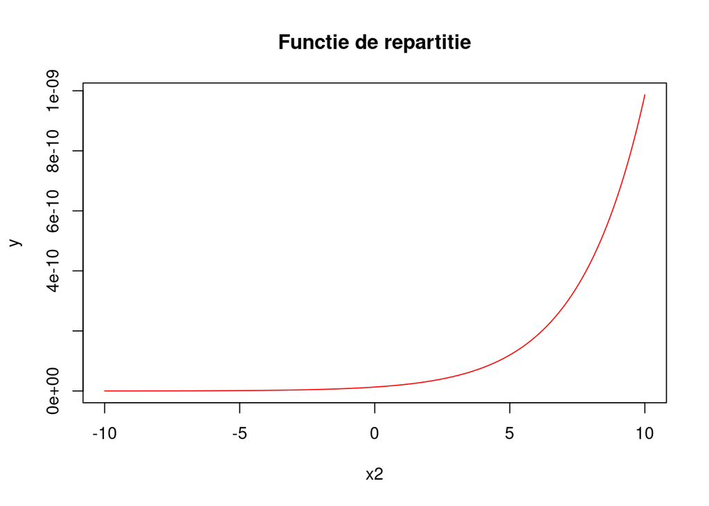

```r
                x2 = seq(-10, 10, length.out = 1000)
                y = F7(x2)
                plot(x2, y, type= "l", col="red", main="Functie de repartitie")
```

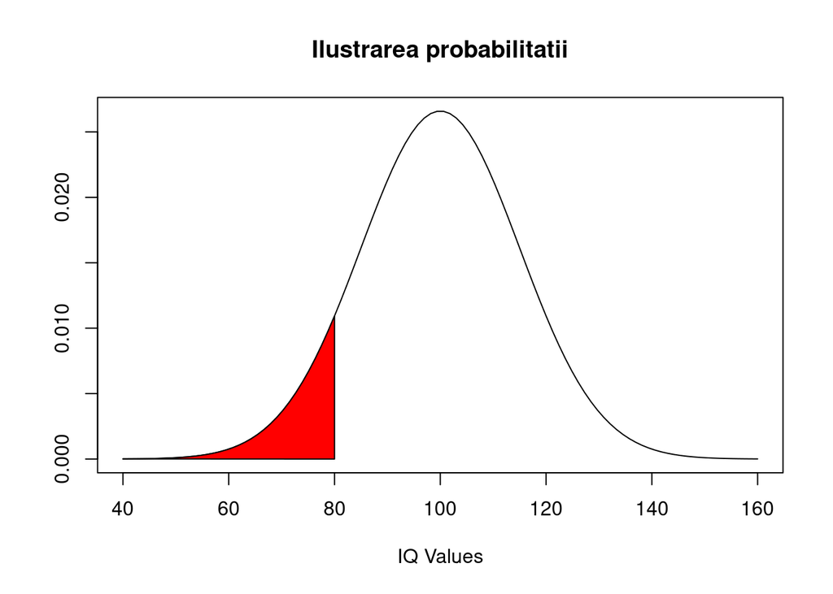

```r
                hx <- dnorm(x1,  Mean,  StDev)
                plot(x1, hx, type = "n", xlab = "IQ Values", ylab = "", main="Ilustrarea probabilitatii")

                SelectProb = "P(x<=a)"
                if( SelectProb=="P(x<=a)"){
                    i <- x1 <=  a
                    lines(x1, hx)
                    polygon(c( a,x1[i]), c(0,hx[i]), col="red")
                }else if( SelectProb=="P(x>=b)"){
                    i <- x >=  b
                    lines(x1, hx)
                    polygon(c( b,x1[i]), c(0,hx[i]), col="red")
                }else{
                    i <- x1 >=  a & x1 <=  b
                    lines(x1, hx)
                    polygon(c( a,x1[i], b), c(0,hx[i],0), col="red")

                    }
```

```r
                if(SelectProb=="P(x<=a)"){
                        c("Probability: ", pnorm( a,  Mean,  StDev))
                    }else if( SelectProb=="P(x>=b)"){
                        c("Probability: ", 1- pnorm( b,  Mean,  StDev))
                    }else{
                        c("Probability: ", pnorm( b,  Mean,  StDev) - pnorm( a,  Mean,  StDev))
                    }
```

```
## [1] "Probability: "      "0.0912112197258678"
```

### Ex 8

Care este probabilitatea sa avem intre A si B vanzari daca vanzarea medie saptamanala este de E (exp_sales) ?

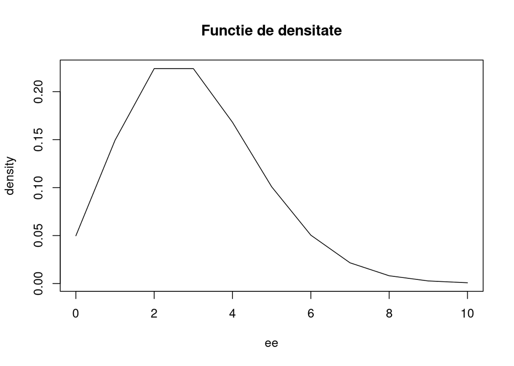

```r
            # 8
            exp_sales = 3
            events = 10

            b = 4


            fd8 = function(x)
            {
                return(dpois(x = x, lambda = exp_sales))
            }

            F8 = function(xx)
            {
                return (ppois(q = xx, lambda = exp_sales, lower.tail = TRUE))
            }

            fctMasa <- ({
                ee = 0:events
                density <- fd8(ee)
                plot (x = ee,y=density,type="l", main="Functie de densitate")
            })
```

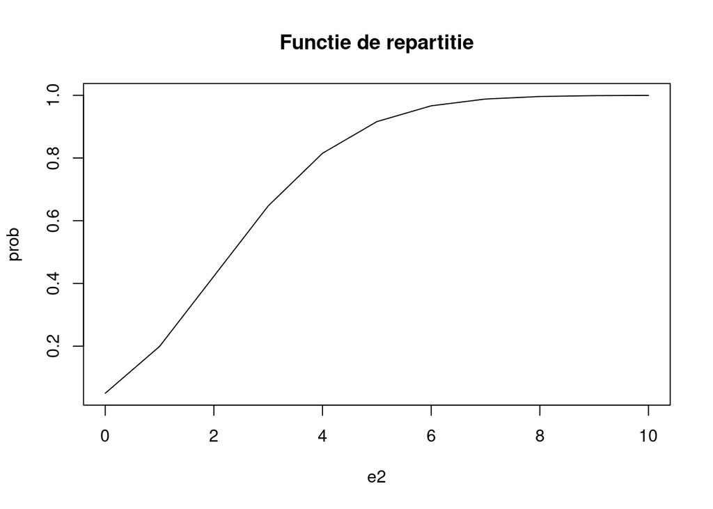

```r
            fctRep <- ({
                e2 = 0:events
                prob <- ppois(q = e2, lambda = exp_sales, lower.tail = TRUE)
                plot (x = e2,y=prob,type="l", main="Functie de repartitie")
            })
```

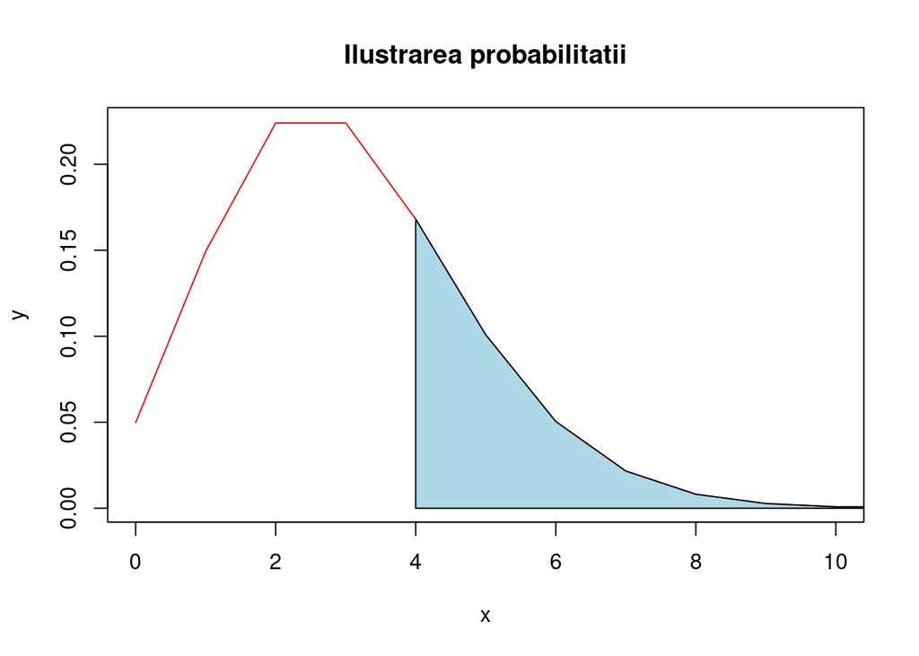

```r
            SelectProb = "P(x>=b)"

            fctProb <- ({
                x = 0:events
                y = fd8(x)

                plot(x, y, type= "l", col="red", main="Ilustrarea probabilitatii")

                if(SelectProb=="P(x<=a)"){
                    polygon(c(0,x[x<=a],a), c(0,y[x<=a],0), col="light blue")
                }else if(SelectProb=="P(x>=b)"){
                    polygon(c(b,x[b<=x],NrInfectati),c(0,y[b<=x],0), col="light blue")
                }else{
                    x = seq(a,b)
                    y = fd8(x)
                    polygon(c(a,x,b), c(0,y,0), col="light blue")
                }
            })
```

```r
            P8 = function(a, b=NULL, param=NULL)
            {
                if(is.null(b))
                {
                    if(is.null(param))
                    {
                        return(F8(a))
                    }
                    else
                    {
                        return (1 - F8 (a))
                    }
                }
                else
                {
                    return (F8(b) - F8(a))
                }
            }



            if(SelectProb=="P(x<=a)"){
                c("Probability: ", P8(a))
            }else if(SelectProb=="P(x>=b)"){
                c("Probability: ", P8(b, param = 1))
            }else{
                c("Probability: ", P8(a, b))

            }
```

```
## [1] "Probability: "     "0.184736755476228"
```

### Ex 9 - Repartitie exponentiala

Se cunoaste timpul mediu pe care un utilizator il petrece pe un site si este calculata probabilitatea ca acesta sa petreaca un numar x de minute pe site.

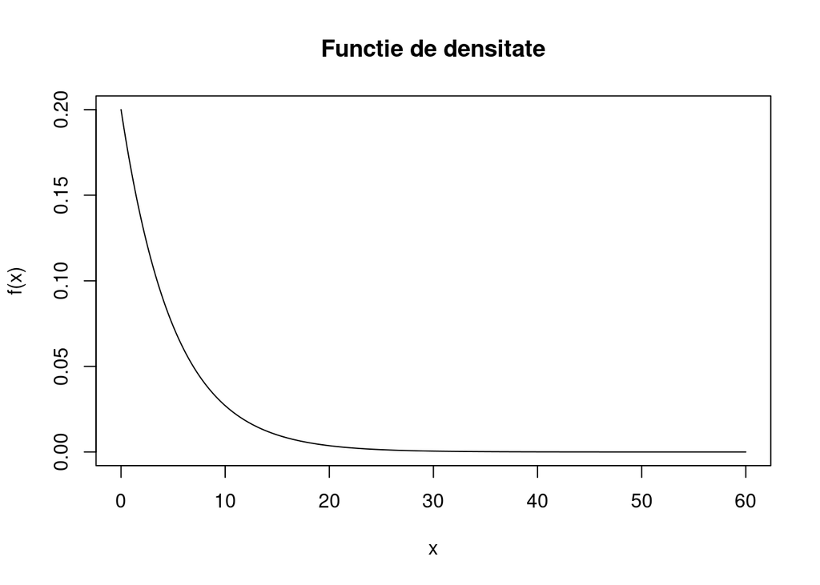

```r
            a = 2
            b = 5
            Time = 5
            x <- seq(0, 12/(1/Time), 0.01)

            y <- dexp(x, rate = 1/Time)
            plot(x, y, type = "n", ylab = "f(x)", main="Functie de densitate")
            lines(x,y)
```

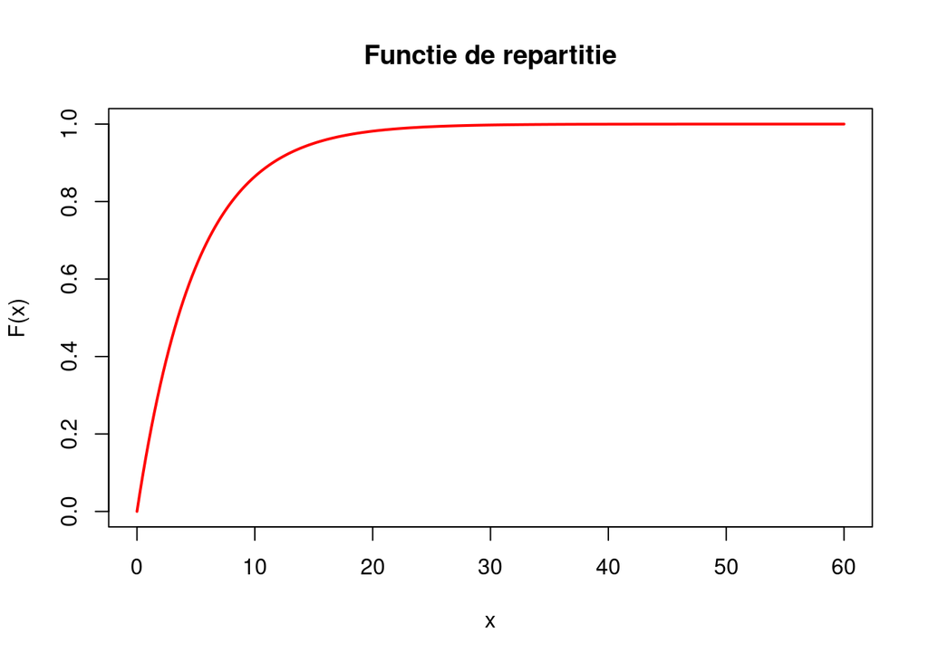

```r
            plot(x, pexp(x, 1/Time), type = "l",
                ylab = "F(x)", lwd = 2, col = "red", main="Functie de repartitie")
```

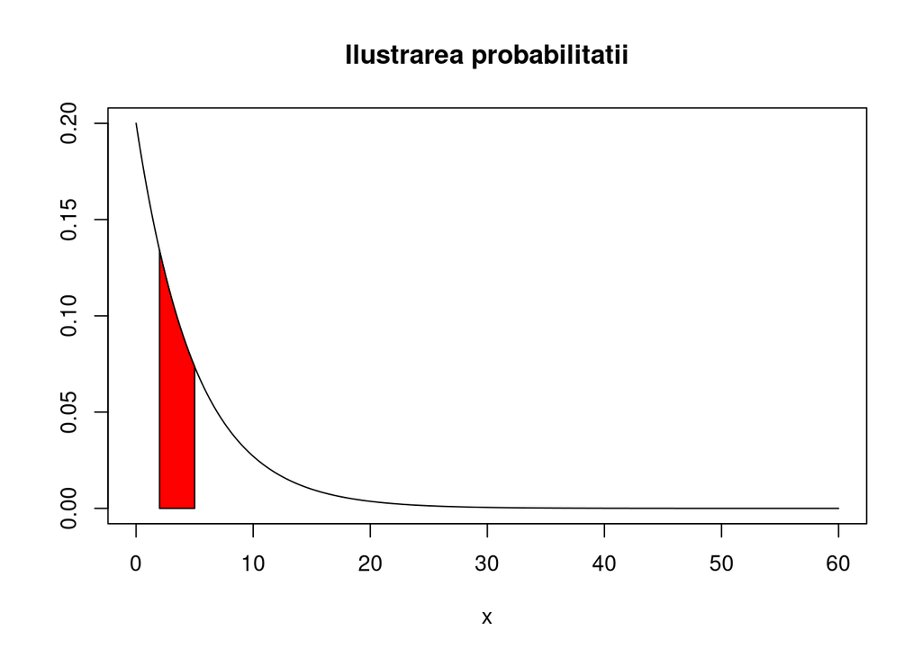

```r
            y <- dexp(x, rate = 1/Time)
            plot(x, y, type = "n", ylab = "", main="Ilustrarea probabilitatii")
            SelectProb = "caz3"
            if(SelectProb=="P(x<=a)"){
                    i <- x <= a
                    lines(x, y)
                    polygon(c(0,x[i],a), c(0,y[i],0), col="red")
            }else if(SelectProb=="P(x>=b)"){
                    i <- x >= b
                    lines(x, y)
                    polygon(c(b,x[i]), c(0,y[i]), col="red")

                    #text(8, 0.12, format(pexp(10, rate = 0.2, lower.tail = FALSE),nsmall = 2), cex = 1.2)
                }else{
                    i <- x >= a & x <= b
                    lines(x, y)
                    polygon(c(a,x[i],b), c(0,y[i],0), col="red")

                }
```

```r
                if(SelectProb=="P(x<=a)"){
                        c("Probability: ", pexp(a, 1/Time))
                }else if(SelectProb=="P(x>=b)"){
                        c("Probability: ", 1 - pexp(b, 1/Time))
                }else{
                        c("Probability: ", pexp(b, 1/Time) - pexp(a, 1/Time))
                }
```

```
## [1] "Probability: "     "0.302440604864197"
```

### Ex 10 (Continua uniforma)

Selectarea a N (nr_test) numere intre A (lim_inf) si B (lim_sup) ?

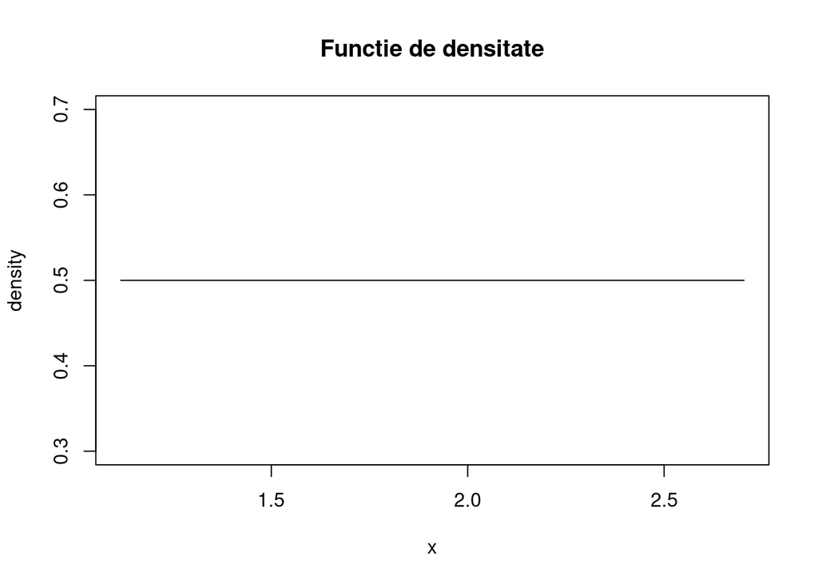

```r
            # 10
            nr_test = 10
            lim_inf = 1
            lim_sup = 3

            a = 2

            fd10 = function(x)
            {
                return(dunif(x = x, min=lim_inf,max=lim_sup))
            }

            F10 = function(xx)
            {
                return (punif(q = xx, min=lim_inf,max=lim_sup, lower.tail = TRUE))
            }


            fctMasa <- ({
                x = runif(nr_test, min = lim_inf, max = lim_sup)
                density <- fd10(x)
                plot (x = x,y=density,type="l", main="Functie de densitate")
            })
```

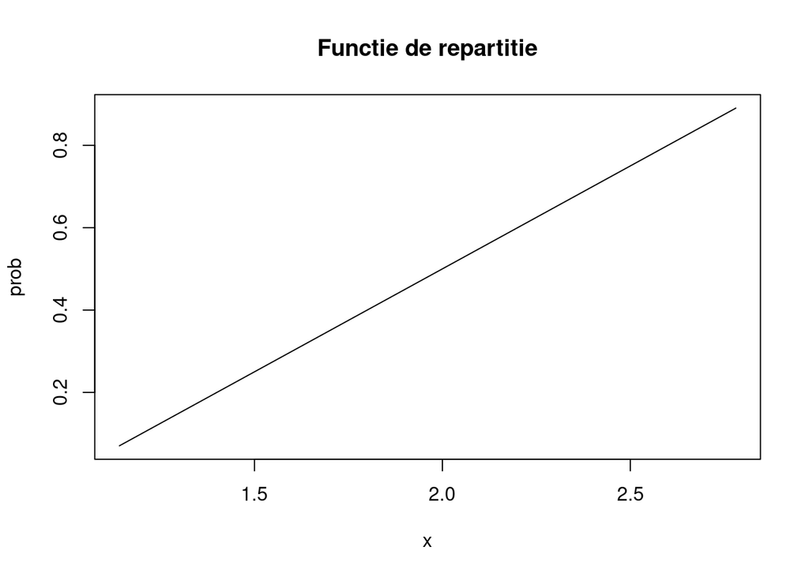

```r
            fctRep <- ({
                x = runif(nr_test, min = lim_inf, max = lim_sup)
                prob <- F10(x)
                plot (x = x,y=prob,type="l", main="Functie de repartitie")
            })
```

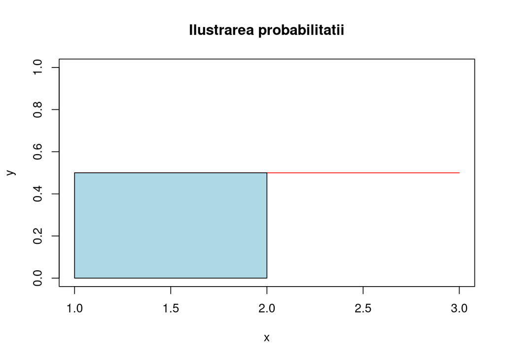

```r
            SelectProb = "P(x<=a)"

            fctProb <-({
                x = seq(lim_inf , lim_sup)
                y = fd10(x)
                mini = min(y)
                plot(x, y, type= "l", col="red", ylim = c(0,1), main="Ilustrarea probabilitatii")
                if(SelectProb=="P(x<=a)"){
                    i <- x <= a
                    polygon(c(lim_inf,x[i],a), c(0,y[i],0), col="light blue")
                }else if(SelectProb=="P(x>=b)"){
                    i <- x >= b
                    polygon(c(b,x[i],lim_sup), c(0,y[i],0), col="light blue")
                }else{

                    x = seq(a , b)
                    y = fd10(x)

                    polygon(c(a,x,b), c(0,y,0), col="light blue")
                }
            })
```

```r
            P10 = function(a, b=NULL, param=NULL)
            {
                if(is.null(b))
                {
                    if(is.null(param))
                    {
                        return(F10(a))
                    }
                    else
                    {
                        return (1 - F10 (a))
                    }
                }
                else
                {
                    return (F10(b) - F10(a))
                }
            }



            if(SelectProb=="P(x<=a)"){
                c("Probability: ", P10(a))
            }else if(SelectProb=="P(x>=b)"){
                c("Probability: ", P10(b, param = 1))
            }else{
                c("Probability: ", P10(a, b))

            }
```

```
## [1] "Probability: " "0.5"
```